# Визуализация в ggplot2: кодим красивое

## Добавляем переменных

Окей, как влияет число стимулов мы поняли. Теперь хотим посмотреть, как на этом фоне ведут себя другие факторы. Добавим тип пробы. Обозначим его, например, цветом:

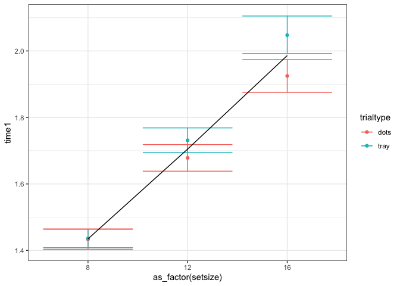

```r
share %>%
  filter(trialtype != "both") %>%
  ggplot(aes(as_factor(setsize), time1,
             color = trialtype)) +
  stat_summary(fun = mean, geom = "point") +
  stat_summary(fun.data = mean_cl_boot, geom = "errorbar") +
  stat_summary(fun = mean, geom = "line",
               aes(group = 1))
```

О, хорошо. Только с линией теперь надо что-то делать. Пока её уберём. И добавим ещё один фактор — используемая платформа смартфона. Пусть он обозначается формой точек:

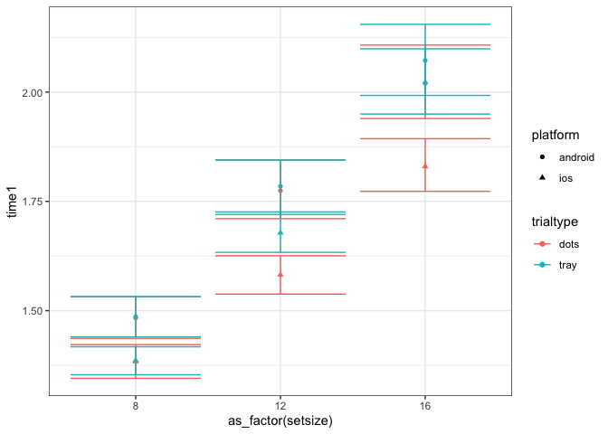

```r
share %>%
  filter(trialtype != "both") %>%
  ggplot(aes(as_factor(setsize), time1,
             color = trialtype,
             shape = platform)) +
  stat_summary(fun = mean, geom = "point") +
  stat_summary(fun.data = mean_cl_boot, geom = "errorbar")
```

Уф… Ну, групировка прошла успешно — уже хорошо, однако отображение хромает. Надо немного раздвинуть точки относительно друг друга в отдельных категориях, так как сейчас они явно друг на друга налезают. Для этого есть аргумент position, который принимает результат выполнения функции `position_dodge()` [^3].

```r
pd <- position_dodge(.3)
```

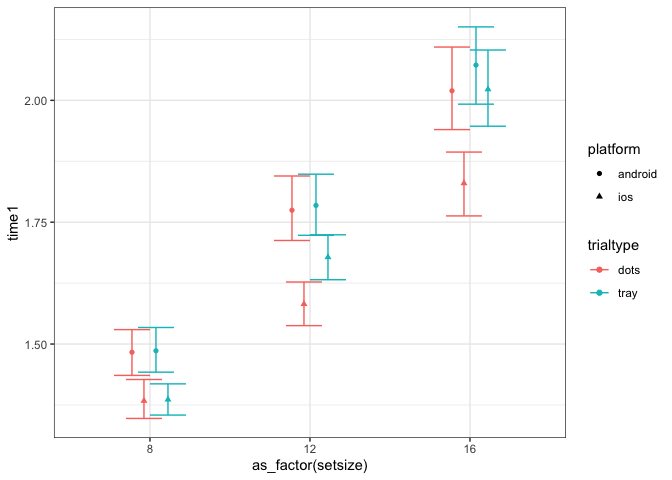

```r
share %>%
  filter(trialtype != "both") %>%
  ggplot(aes(as_factor(setsize), time1,
             color = trialtype,
             shape = platform)) +
  stat_summary(fun = mean, geom = "point",
               position = pd) +
  stat_summary(fun.data = mean_cl_boot, geom = "errorbar",
               position = pd)
```

Ага, ну, норм. Только «усы» доверительных интервалов широки — надо сделать их поуже:

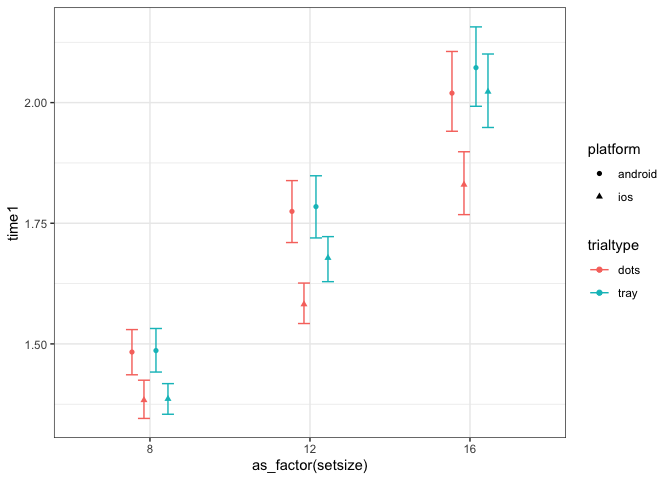

```r
share %>%
  filter(trialtype != "both") %>%
  ggplot(aes(as_factor(setsize), time1,
             color = trialtype,
             shape = platform)) +
  stat_summary(fun = mean, geom = "point",
               position = pd) +
  stat_summary(fun.data = mean_cl_boot, geom = "errorbar",
               position = pd, width = .3)
```

Красuво!

Осталось только понять, как бы нам вернуть линии. Осмыслим, что нам надо соединить красные треугольники между собой, зелёные треугольники между собой, красный точки между собой и зелёные точки между собой. То есть группы точек у нас получаются в результате взаимодействия факторов. Так и напишем:

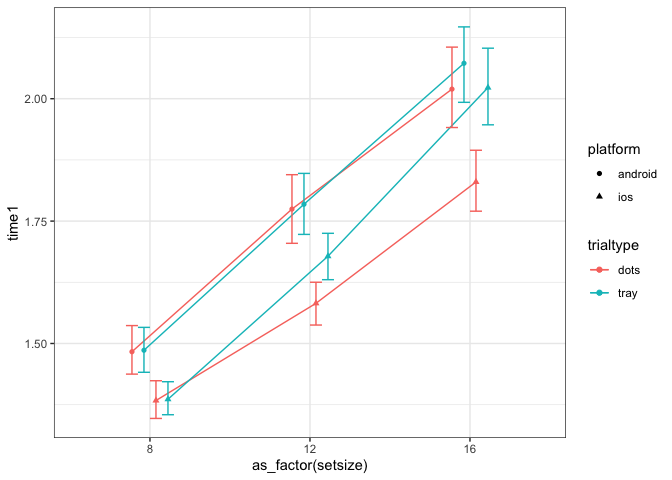

```r
share %>%
  filter(trialtype != "both") %>%
  ggplot(aes(as_factor(setsize), time1,
             color = trialtype,
             shape = platform,
             group = interaction(trialtype, platform))) +
  stat_summary(fun = mean, geom = "line",
               position = pd) +
  stat_summary(fun.data = mean_cl_boot, geom = "errorbar",
               position = pd, width = .3) +
  stat_summary(fun = mean, geom = "point",
               position = pd)
```

## Наводим красоту

Сделаем то, что мы уже умеем: увеличим размер точек, сдвинем легенду вниз, подпишем переменные. Попутно сделаем линни пунктирными, чтобы не сильно отвлекали внимание:

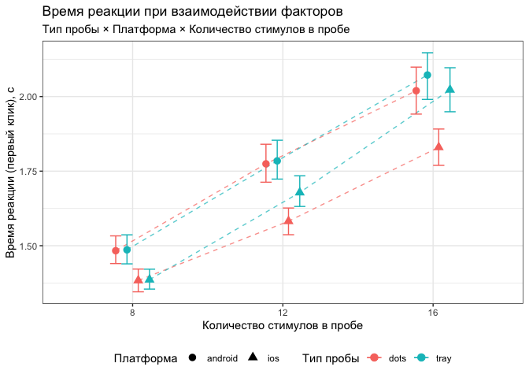

```r
share %>%
  filter(trialtype != "both") %>%
  ggplot(aes(as_factor(setsize), time1,
             color = trialtype,
             shape = platform,
             group = interaction(trialtype, platform))) +
  stat_summary(fun = mean, geom = "line",
               position = pd, linetype = "dashed", alpha = .7) +
  stat_summary(fun.data = mean_cl_boot, geom = "errorbar",
               position = pd, width = .3) +
  stat_summary(fun = mean, geom = "point",
               position = pd, size = 3) +
  labs(x = "Количество стимулов в пробе",
       y = "Время реакции (первый клик), с",
       color = "Тип пробы",
       shape = "Платформа",
       title = "Время реакции при взаимодействии факторов",
       subtitle = "Тип пробы × Платформа × Количество стимулов в пробе") +
  theme(legend.position = "bottom")
```

Оч хор. Вот только мы отобразили интервальную оценку на графике, а ведь это может быть не только доверительный интервал — так же выглядит и стандартная ошибка и даже стандартное отклонение. Надо подписать в подписи:

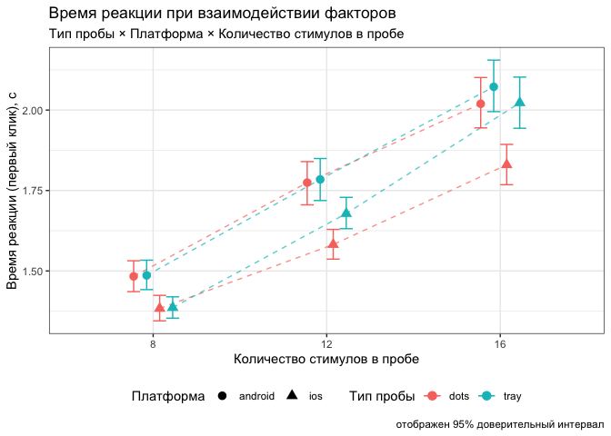

```r
share %>%
  filter(trialtype != "both") %>%
  ggplot(aes(as_factor(setsize), time1,
             color = trialtype,
             shape = platform,
             group = interaction(trialtype, platform))) +
  stat_summary(fun = mean, geom = "line",
               position = pd, linetype = "dashed", alpha = .7) +
  stat_summary(fun.data = mean_cl_boot, geom = "errorbar",
               position = pd, width = .3) +
  stat_summary(fun = mean, geom = "point",
               position = pd, size = 3) +
  labs(x = "Количество стимулов в пробе",
       y = "Время реакции (первый клик), с",
       color = "Тип пробы",
       shape = "Платформа",
       title = "Время реакции при взаимодействии факторов",
       subtitle = "Тип пробы × Платформа × Количество стимулов в пробе",
       caption = "отображен 95% доверительный интервал") +
  theme(legend.position = "bottom")
```

Ну, почти всё. Осталось только красиво подписать платформы и типы проб. Для этого есть функции семейства `scale_*()`. Работает это так:

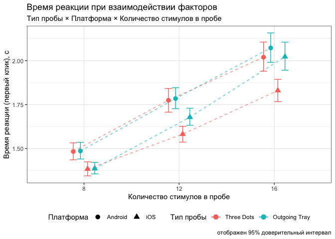

```r
share %>%
  filter(trialtype != "both") %>%
  ggplot(aes(as_factor(setsize), time1,
             color = trialtype,
             shape = platform,
             group = interaction(trialtype, platform))) +
  stat_summary(fun = mean, geom = "line",
               position = pd, linetype = "dashed", alpha = .7) +
  stat_summary(fun.data = mean_cl_boot, geom = "errorbar",
               position = pd, width = .3) +
  stat_summary(fun = mean, geom = "point",
               position = pd, size = 3) +
  labs(x = "Количество стимулов в пробе",
       y = "Время реакции (первый клик), с",
       color = "Тип пробы",
       shape = "Платформа",
       title = "Время реакции при взаимодействии факторов",
       subtitle = "Тип пробы × Платформа × Количество стимулов в пробе",
       caption = "отображен 95% доверительный интервал") +
  scale_color_discrete(labels = c("Three Dots", "Outgoing Tray")) +
  scale_shape_discrete(labels = c("Android", "iOS")) +
  theme(legend.position = "bottom")
```

Супер! Отправляем в журнал!

## Кастомизация шкал

Но недолго мы радовались: пришло письмо от редактора. Краткое содержание — «очень хороший, отличный, прекрасный график! переделайте, пожалуйста». Редактору не понравилось использование цвета — журнал печатается в черно-белом варианте.

Ок, секудочку.

Мы уже приступили к кастомизации шкал, когда задавали лейблы для уровней наших категориальных переменных. Теперь включим кастом на всю силу — используем функции `scale_*_manual()`:

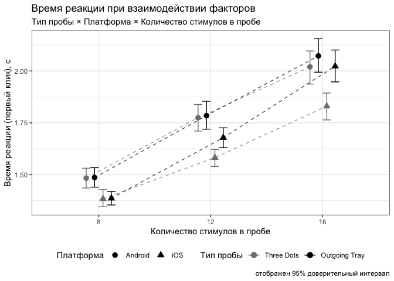

```r
share %>%
  filter(trialtype != "both") %>%
  ggplot(aes(as_factor(setsize), time1,
             color = trialtype,
             shape = platform,
             group = interaction(trialtype, platform))) +
  stat_summary(fun = mean, geom = "line",
               position = pd, linetype = "dashed", alpha = .7) +
  stat_summary(fun.data = mean_cl_boot, geom = "errorbar",
               position = pd, width = .3) +
  stat_summary(fun = mean, geom = "point",
               position = pd, size = 3) +
  labs(x = "Количество стимулов в пробе",
       y = "Время реакции (первый клик), с",
       color = "Тип пробы",
       shape = "Платформа",
       title = "Время реакции при взаимодействии факторов",
       subtitle = "Тип пробы × Платформа × Количество стимулов в пробе",
       caption = "отображен 95% доверительный интервал") +
  scale_color_manual(values = c("gray50", "black"),
                     labels = c("Three Dots", "Outgoing Tray")) +
  scale_shape_discrete(labels = c("Android", "iOS")) +
  theme(legend.position = "bottom")
```

Здесь мы задаём цвета через [названия](https://github.com/angelgardt/mk_ggplot2/blob/master/Rcolor.pdf). Можно также использовать [HEX code](https://www.w3schools.com/colors/colors_hexadecimal.asp).

## Шрифт

Ещё редактору не понравился шрифт без засечек — он хочет Times New Roman.

Ок, секудочку.

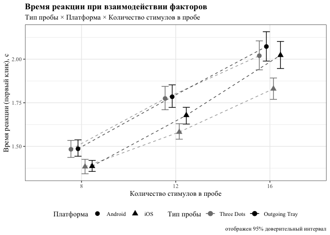

```r
share %>%
  filter(trialtype != "both") %>%
  ggplot(aes(as_factor(setsize), time1,
             color = trialtype,
             shape = platform,
             group = interaction(trialtype, platform))) +
  stat_summary(fun = mean, geom = "line",
               position = pd, linetype = "dashed", alpha = .7) +
  stat_summary(fun.data = mean_cl_boot, geom = "errorbar",
               position = pd, width = .3) +
  stat_summary(fun = mean, geom = "point",
               position = pd, size = 3) +
  labs(x = "Количество стимулов в пробе",
       y = "Время реакции (первый клик), с",
       color = "Тип пробы",
       shape = "Платформа",
       title = "Время реакции при взаимодействии факторов",
       subtitle = "Тип пробы × Платформа × Количество стимулов в пробе",
       caption = "отображен 95% доверительный интервал") +
  scale_color_manual(values = c("gray50", "black"),
                     labels = c("Three Dots", "Outgoing Tray")) +
  scale_shape_discrete(labels = c("Android", "iOS")) +
  theme(legend.position = "bottom",
        title = element_text(family = "Times New Roman"),
        plot.title = element_text(face = "bold"),
        axis.text = element_text(family = "Times New Roman"),
        legend.text = element_text(family = "Times New Roman"))
```

Ну, вот теперь редактор доволен.

# Сохранение графиков

Для того, чтобы опубликовать график в статье или даже просто вставить в презентацию нужно его как-то выгрузить. Скриншоты нам не подходят, потому что качество их совершенно никуда не годится. На наше счастье есть фукнция для выгрузки картинок из `R` и называется она `ggsave()`.

Она принимает следующие аргументы:

- `filename` — название файла, в которых будет сохранен график
- `plot` — график, который необходимо сохранить (по умолчанию, последний построенный)
- `scale` — степень масштабирования изображения
- `width` — ширина изображения
- `height` — высота изображения
- `units` — единицы изменения (дюймы, миллиметры, сантиметры)
- `dpi` — разрешение изображения (точки на дюйм)

Функция позволяет сохранить изображения большинства форматов (JPEG, PNG, SVG, TIFF, PDF).

```r
ggsave('graph1.png', width = 20, height = 20, units = 'cm', dpi = "print")
```

Выполнив эту функцию мы получим в рабочей директории файл с графиком, который мы только что нарисовали.

> Вот и весь основной flow, которому можно следовать при создании публикабельных графиков. А если этого уже мало, то вполне можно нырять в [невероятное чтиво](https://www.springer.com/gp/book/9780387981413) и бороздить [Google](https://google.com/) вопросами о конкретных вещах — на [Stack Overflow](https://stackoverflow.com/) найдется ответ практически на любой вопрос. Успехов!

# Необычные фишечки [2]

> Для искушенных

Пошалим! Возьмем опросник:

```r
taia <- read_csv("https://raw.githubusercontent.com/angelgardt/angelgardt.github.io/master/appcogsci2022/taia_sample.csv")
```

Предобработаем — посчитаем суммарный балл по шкалам:

```r
taia %>%
  pivot_longer(1:60, names_to = "item", values_to = "score") %>%
  mutate(subscale = str_remove_all(item, "[:digit:]{2}") %>% toupper()) %>%
  group_by(id, subscale) %>%
  summarise(subscale_score = sum(score))
```

```
## # A tibble: 300 x 3
## # Groups:   id [50]
##       id subscale subscale_score
##    <dbl> <chr>             <dbl>
##  1     1 CO                   18
##  2     1 DE                   19
##  3     1 FA                   13
##  4     1 PR                   24
##  5     1 UN                   29
##  6     1 UT                   27
##  7     2 CO                   21
##  8     2 DE                   18
##  9     2 FA                   14
## 10     2 PR                   19
## # … with 290 more rows
```

Попробуем отобразить профили нескольких респондентов. Например, 5-го, 23-го и 50-го. Заодно и крусоту наведем.

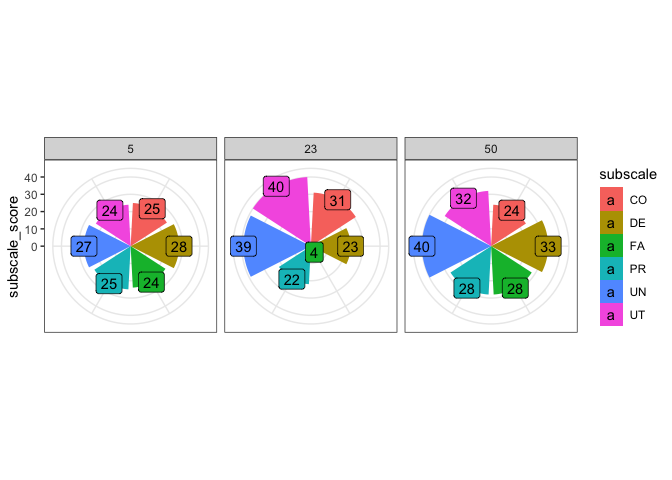

```r
taia %>%
  pivot_longer(1:60, names_to = "item", values_to = "score") %>%
  mutate(subscale = str_remove_all(item, "[:digit:]{2}") %>% toupper()) %>%
  group_by(id, subscale) %>%
  summarise(subscale_score = sum(score)) %>%
  filter(id == 5 | id == 23 | id == 50) %>%
  ggplot(aes(subscale, subscale_score, fill = subscale)) +
  geom_col() +
  geom_label(aes(label = subscale_score)) +
  facet_wrap(~ id) +
  coord_polar() +
  theme(axis.title.x = element_text(size = 0),
        axis.text.x = element_text(size = 0))
```

Как это получилось? Обратите внимание на геомы: по факту мы построили столбчатую диаграмму — `geom_col()`. Второй геом `geom_label()` всего лишь навесил нам циферки в квадратиках. С фасетами мы тоже уже знакомы.

А потом мы сделали `coord_polar()`. Здесь нам надо вспомнить, что существует не только декартова система координат. В данном случае мы завернули привычный нам график в декартовых координатах в [*полярную систему координат*](https://ru.wikipedia.org/wiki/Полярная_система_координат). Давайте посмотрим на график без `coord_polar()`:

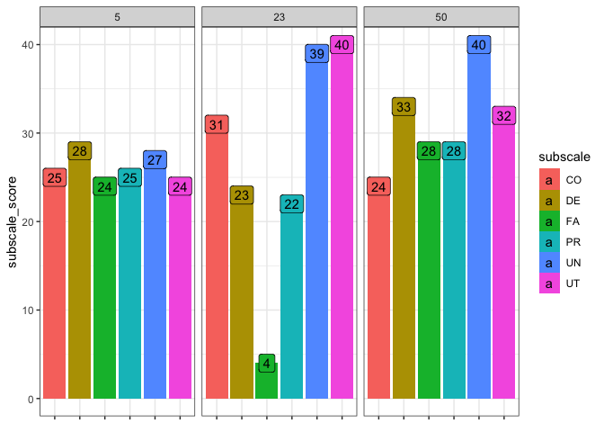

```r
taia %>%
  pivot_longer(1:60, names_to = "item", values_to = "score") %>%
  mutate(subscale = str_remove_all(item, "[:digit:]{2}") %>% toupper()) %>%
  group_by(id, subscale) %>%
  summarise(subscale_score = sum(score)) %>%
  filter(id == 5 | id == 23 | id == 50) %>%
  ggplot(aes(subscale, subscale_score, fill = subscale)) +
  geom_col() +
  geom_label(aes(label = subscale_score)) +
  facet_wrap(~ id) +
  # coord_polar() +
  theme(axis.title.x = element_text(size = 0),
        axis.text.x = element_text(size = 0))
```

Реально же, все крайне привычно! В `theme()` в данном случае убрана дублируемая информация, так как для наглядности `subscale` отображены также цветом заливки.

А еще можно пилить мемы:

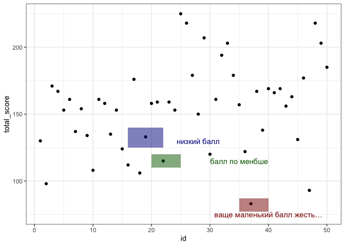

[figure not shown]

```r
taia %>%
  pivot_longer(1:60, names_to = "item", values_to = "score") %>%
  mutate(subscale = str_remove_all(item, "[:digit:]{2}") %>% toupper()) %>%
  group_by(id) %>%
  summarise(total_score = sum(score)) %>%
  ggplot(aes(id, total_score)) +
  geom_point() +
  annotate("rect", xmin = 16, xmax = 22, ymin = 125, ymax = 140,
           fill = "darkblue", alpha = .5) +
  annotate("text", x = 28, y = 130,
           label = "низкий балл", color = "darkblue") +
  annotate("rect", xmin = 20, xmax = 25, ymin = 110, ymax = 120,
           fill = "darkgreen", alpha = .5) +
  annotate("text", x = 35, y = 115,
           label = "балл по менбше", color = "darkgreen") +
  annotate("rect", xmin = 35, xmax = 40, ymin = 77, ymax = 87,
           fill = "darkred", alpha = .5) +
  annotate("text", x = 40, y = 75,
           label = "ваще маленький балл жесть…", color = "darkred")
```

Вот такое можно изображать в ггплоте.

[^1]: Шок…
[^2]: Ибо «нормально делай — нормально будет».
[^3]: Есть и другие `position_*()`, но мы их упустим